# Kurze Ergänzung meines CVs

## Mein Leben in Zürich aus der Sicht von Google

Veröffentlichung: 5. 6. 2020  
Autor: David Hanimann

Google weiss mehr über mich als ich selber. Die mittlerweile knapp 13 GB Daten, die bei Google meine Person beschreiben, kann ich von Google anfordern. Neben tausenden von Emails und Fotos weiss der Datengigant auch sehr genau, wie ich mich im Raum bewege.

Hier also eine kurze Übersicht meines Lebens in Zürich:

### Trackpoints in der Stadt Zürich

Von 186'767 Aufenthaltsorten von mir weiss Google Bescheid.

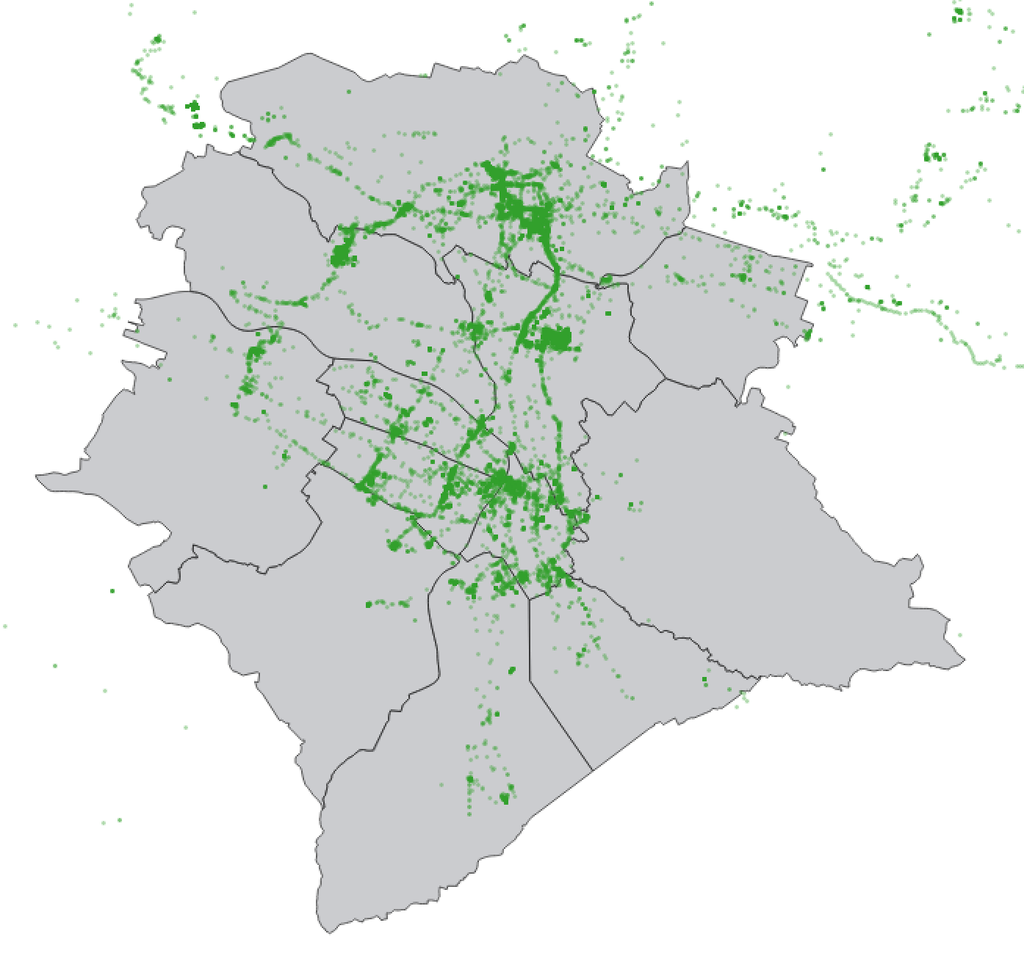

In Kreis 11 habe ich offenbar am meisten zu tun, hier wohnte ich während mehrerer Jahre. In Kreis 6 befindet sich die Uni Irchel, deshalb war ich auch da oft anzutreffen.

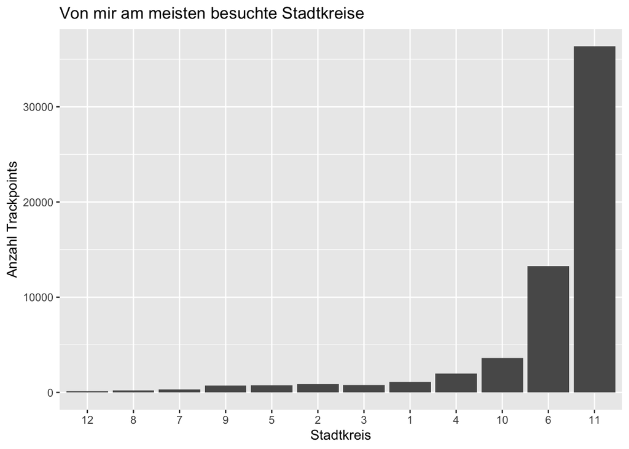

Google berechnet für jeden Trackpoint auf welche Art ich mich bewege, zu Fuss, mit dem Velo, ÖV oder gar nicht. Nach Kreisen sieht das so aus:

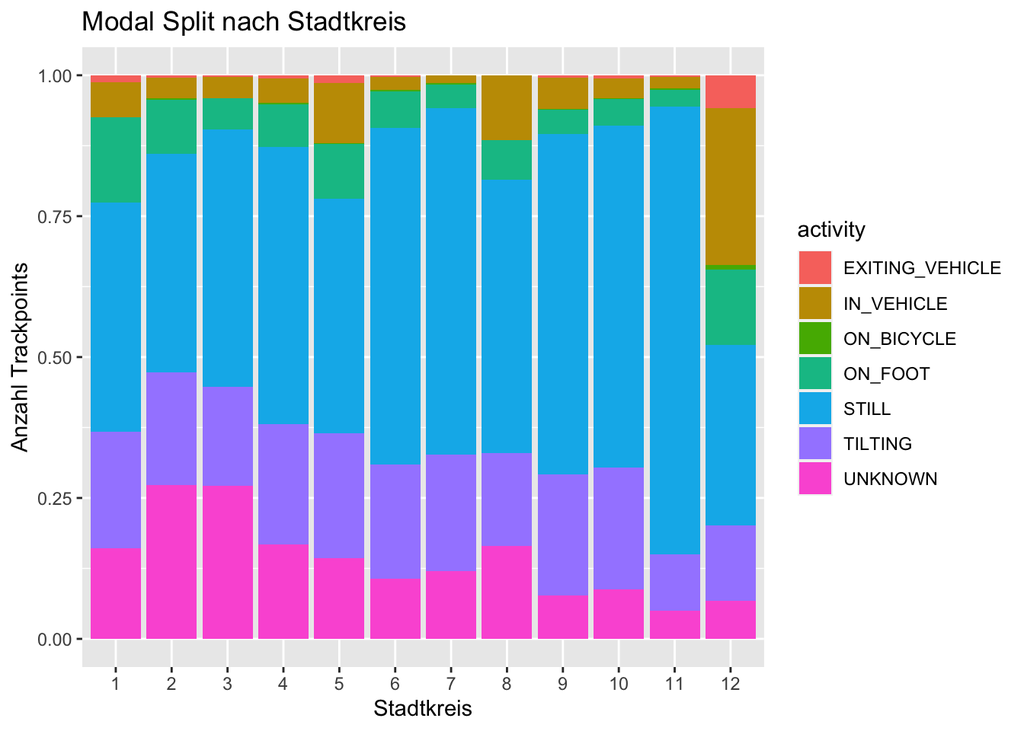

Es zeigt sich, dass Kreis 1, 5, 8 und 12 für mich Orte sind, die ich durchquere aber in denen ich nicht verweile.

Diese Auswertungen deuten nur an, wwas für ein Ausmass an Informationen die kumulierten Daten aller Google-Nutzer bergen. Wie bewegen sich Menschen fort, wieviel Sport treibt eine Person? Mit welchen Leute geht jemand an bestimmte Orte? Welche Restaurants, welche Geschäfte besuchen junge Leute? Wo wird gewohnt, wo gearbeitet? Oder: wer nimmt an unbewilligten Demonstrationen teil? Google weiss darüber wie kaum jemand Bescheid.